# OkCupid Dating Profile Analysis

By Ritvik Yaragudipati and Renee Sen

[figure not shown]

OkCupid is a free popular online dating application created in 2004 that uses a matching algorithm to help users find potential partners. OkCupid asks users to fill out a questionnaire and create a profile with personal information and photos, which is then used to find compatible matches. The website has a variety of features, such as the ability to message other users and attend events, to help users connect with potential partners. It is owned by Match Group, which is also who owns the other popular dating applications, like Tinder, Hinge, and others.

The dataset being used in this analysis contains 60,000 records of anonymous user answers to the questionnaire from 2012. It includes data of basic information like gender, orientation, to more personalized information in the profile text column.

This tutorial will lead you through the process of cleaning up the data (dealing with different human responses, gibberish text in the columns, renaming columns/responses for ease of understanding, etc.), and then analyzing the data through the use of visuals. With this information, we will determine/predict what type of factors are most successful in creating a match. We hope that our readers will come out being aware of what may be more important to emphasize in profiles.

This of course is not to dissuade users from personalizing their profiles in the way they want or cause them change themselves to fit other's standards. This data is from 10 years ago, so it would be interesting to see how the dating scene was back then compared to now. What factors would lead to relationships from 10 years ago? Future work would be to compare a more recent dataset.

Feel free to challenge the predictions!

We will begin by importing the libraries we need. This will include libaries that can help us with data cleaning to libraries that can help us visualize and then create our predictions.

Take the time to go onto the libraries API to understand the different functions there are and what they do.

```python
import pandas as pd
import matplotlib.pylab as plt
import seaborn as sns
import numpy as np
import warnings
from sklearn.preprocessing import LabelEncoder
from sklearn.neighbors import KNeighborsClassifier
from sklearn.model_selection import train_test_split
from sklearn import preprocessing
from sklearn import tree
from sklearn.ensemble import RandomForestClassifier
from sklearn.naive_bayes import MultinomialNB
from sklearn.feature_extraction.text import CountVectorizer
from sklearn.utils import shuffle
from sklearn.svm import SVC
from sklearn.metrics import confusion_matrix,classification_report
from sklearn.model_selection import cross_val_score, GridSearchCV
from sklearn.metrics import accuracy_score
from scipy.stats import pearsonr


warnings.filterwarnings('ignore')
```

```python
from google.colab import drive
drive.mount('/content/drive')
```

# Part 1: Data Collection

We will now start by loading in our data. Since we have a csv file, we can use the pandas library function called read_csv. If you have a different form of this data (not a csv), there might be a special function to read the data type you have.

```python
# Loading in data
data = pd.read_csv('/content/drive/MyDrive/Fall 2022/cmsc320/final/okcupid_profiles.csv')
```

So what different categories are we dealing with? This dataset has 31 different columns:

- Age
- Status
- Sex, Orientation
- Body type, Diet
- Drinks, Drugs
- Education
- Ethnicity
- Height
- Income
- Job
- Last Online
- Location
- Offspring
- Pets
- Religion
- Sign
- Smokes
- Speaks (Language)
- Essays (0-9)

We have a lot to explore so lets get into it!

# Part 2: Data Cleaning

When we load in the data we will see that a lot of the data inside the table needs a lot of cleaning or changing to make it easier for us to work with.

In our data set, we have multiple essay categories that could essentially just go into one category. So, we did exactly that. We located all the columns with essays, and combined them into one category called "profile text".

We also needed to make sure that if there was any profile texts that had "NA", that we would explicitly put "No Info". While we could've left it alone, it would be more detailed for us to make it clear that it had no info.

Combining the essays also can give us another metric that we can use for analysis: "Total Words". How much do people actually write in their essays?

```python
# Combining essays into 1 profile text
data["profile text"] = (data["essay0"].str.cat(data.iloc[:,22:-1].astype(str), sep=" "))

# dropping all the extra columns
data=data.drop(data.iloc[:,21:-1], axis=1)
# if there are any NA columns
data["profile text"]=data["profile text"].fillna("No info")

# creating a column for the total amount of words in all the essays
data["Total Words"]=data["profile text"].str.split().str.len()

data.head()
```

|  | age | status | sex | orientation | body_type | diet | drinks | drugs | education | ethnicity | ... | last_online | location | offspring | pets | religion | sign | smokes | speaks | profile text | Total Words |
| --- | --- | --- | --- | --- | --- | --- | --- | --- | --- | --- | --- | --- | --- | --- | --- | --- | --- | --- | --- | --- | --- |
| 0 | 22 | single | m | straight | a little extra | strictly anything | socially | never | working on college/university | asian, white | ... | 2012-06-28-20-30 | south san francisco, california | doesn't have kids, but might want them | likes dogs and likes cats | agnosticism and very serious about it | gemini | sometimes | english | about me: i would love to think that i was so... | 420 |
| 1 | 35 | single | m | straight | average | mostly other | often | sometimes | working on space camp | white | ... | 2012-06-29-21-41 | oakland, california | doesn't have kids, but might want them | likes dogs and likes cats | agnosticism but not too serious about it | cancer | no | english (fluently), spanish (poorly), french (... | i am a chef: this is what that means. 1. i am ... | 271 |
| 2 | 38 | available | m | straight | thin | anything | socially | NaN | graduated from masters program | NaN | ... | 2012-06-27-09-10 | san francisco, california | NaN | has cats | NaN | pisces but it doesn&rsquo;t matter | no | english, french, c++ | i'm not ashamed of much, but writing public te... | 819 |
| 3 | 23 | single | m | straight | thin | vegetarian | socially | NaN | working on college/university | white | ... | 2012-06-28-14-22 | berkeley, california | doesn't want kids | likes cats | NaN | pisces | no | english, german (poorly) | i work in a library and go to school. . . read... | 74 |
| 4 | 29 | single | m | straight | athletic | NaN | socially | never | graduated from college/university | asian, black, other | ... | 2012-06-27-21-26 | san francisco, california | NaN | likes dogs and likes cats | NaN | aquarius | no | english | hey how's it going? currently vague on the pro... | 109 |

5 rows × 23 columns

Next we can see we have a status column. This column is important as it will serve to be what we are predicting based one certain factors. There are multiple ways to convey status, so it would be useful to narrow it down to just single and taken.

We can do that by replacing all the values that represent single to single and replace all the values that represent taken to taken.

We will also make sure to store these rows specific to single or taken for later use in testing our predictions.

```python
# We want to sepreate our data between people who are single and people who are taken

# looking at the different values
data['status'].unique()

# both single and available mean single
singlevalues = ['single', 'available']
# both seeing someone and married mean taken
takenvalues = ['seeing someone', 'married']

# gettig all the values that are single/taken and putting into a mask
mask = data['status'].isin(singlevalues)
mask2 = data['status'].isin(takenvalues)
single = data.loc[mask]
taken = data.loc[mask2]

# replacing all availables with single
single.replace('available', 'single', inplace = True)

# replacing all seeing someone and married with taken
taken.replace('seeing someone', 'taken', inplace = True)
taken.replace('married', 'taken', inplace = True)

print('single: ', single['status'].unique() ,
      '\nTaken: ', taken['status'].unique())
```

```
single:  ['single']
Taken:  ['taken']
```

It is also very important to find where there are null values as that could affect our predictions. We can do this by finding the number of nulls in each columns. How should we deal with the nulls, is the next question.

```python
#Finding the number of null values in our data set
null_counts = data.isnull().sum()
print(null_counts)
```

```
age                 0
status              0
sex                 0
orientation         0
body_type        5296
diet            24395
drinks           2985
drugs           14080
education        6628
ethnicity        5680
height              3
income              0
job              8198
last_online         0
location            0
offspring       35561
pets            19921
religion        20226
sign            11056
smokes           5512
speaks             50
profile text        0
Total Words         0
dtype: int64
```

We will turn the sex column into a datatype category. Not only does this help save space, but it will help us more easily when using it for data exploration.

```python
# Turn the sex into 2 categories
data["sex"]=data["sex"].astype("category")
data["sex"].cat.set_categories(["m","f"], inplace=True)
data.head()
```

|  | age | status | sex | orientation | body_type | diet | drinks | drugs | education | ethnicity | ... | last_online | location | offspring | pets | religion | sign | smokes | speaks | profile text | Total Words |
| --- | --- | --- | --- | --- | --- | --- | --- | --- | --- | --- | --- | --- | --- | --- | --- | --- | --- | --- | --- | --- | --- |
| 0 | 22 | single | m | straight | a little extra | strictly anything | socially | never | working on college/university | asian, white | ... | 2012-06-28-20-30 | south san francisco, california | doesn't have kids, but might want them | likes dogs and likes cats | agnosticism and very serious about it | gemini | sometimes | english | about me: i would love to think that i was so... | 420 |
| 1 | 35 | single | m | straight | average | mostly other | often | sometimes | working on space camp | white | ... | 2012-06-29-21-41 | oakland, california | doesn't have kids, but might want them | likes dogs and likes cats | agnosticism but not too serious about it | cancer | no | english (fluently), spanish (poorly), french (... | i am a chef: this is what that means. 1. i am ... | 271 |
| 2 | 38 | available | m | straight | thin | anything | socially | NaN | graduated from masters program | NaN | ... | 2012-06-27-09-10 | san francisco, california | NaN | has cats | NaN | pisces but it doesn&rsquo;t matter | no | english, french, c++ | i'm not ashamed of much, but writing public te... | 819 |
| 3 | 23 | single | m | straight | thin | vegetarian | socially | NaN | working on college/university | white | ... | 2012-06-28-14-22 | berkeley, california | doesn't want kids | likes cats | NaN | pisces | no | english, german (poorly) | i work in a library and go to school. . . read... | 74 |
| 4 | 29 | single | m | straight | athletic | NaN | socially | never | graduated from college/university | asian, black, other | ... | 2012-06-27-21-26 | san francisco, california | NaN | likes dogs and likes cats | NaN | aquarius | no | english | hey how's it going? currently vague on the pro... | 109 |

5 rows × 23 columns

Now for some more data cleaning. If we take a look at the sign column, we can see what sign the user is and some words after it. Now, not all the users have some words after it.

Let's begin by partitioning by the spaces and then we will put the respective sign in the "sign" column and then put any other information in a "sign_sig" column

```python
# splitting the values by space
df_split = data["sign"].str.partition(" ")

# gets everything after the sign
data['sign_sig'] = df_split.iloc[:, 2]

# gets the first value, which is the sign
data['sign'] = df_split.iloc[:, 0]

data
```

|  | age | status | sex | orientation | body_type | diet | drinks | drugs | education | ethnicity | ... | location | offspring | pets | religion | sign | smokes | speaks | profile text | Total Words | sign_sig |
| --- | --- | --- | --- | --- | --- | --- | --- | --- | --- | --- | --- | --- | --- | --- | --- | --- | --- | --- | --- | --- | --- |
| 0 | 22 | single | m | straight | a little extra | strictly anything | socially | never | working on college/university | asian, white | ... | south san francisco, california | doesn't have kids, but might want them | likes dogs and likes cats | agnosticism and very serious about it | gemini | sometimes | english | about me: i would love to think that i was so... | 420 |  |
| 1 | 35 | single | m | straight | average | mostly other | often | sometimes | working on space camp | white | ... | oakland, california | doesn't have kids, but might want them | likes dogs and likes cats | agnosticism but not too serious about it | cancer | no | english (fluently), spanish (poorly), french (... | i am a chef: this is what that means. 1. i am ... | 271 |  |
| 2 | 38 | available | m | straight | thin | anything | socially | NaN | graduated from masters program | NaN | ... | san francisco, california | NaN | has cats | NaN | pisces | no | english, french, c++ | i'm not ashamed of much, but writing public te... | 819 | but it doesn&rsquo;t matter |
| 3 | 23 | single | m | straight | thin | vegetarian | socially | NaN | working on college/university | white | ... | berkeley, california | doesn't want kids | likes cats | NaN | pisces | no | english, german (poorly) | i work in a library and go to school. . . read... | 74 |  |
| 4 | 29 | single | m | straight | athletic | NaN | socially | never | graduated from college/university | asian, black, other | ... | san francisco, california | NaN | likes dogs and likes cats | NaN | aquarius | no | english | hey how's it going? currently vague on the pro... | 109 |  |
| ... | ... | ... | ... | ... | ... | ... | ... | ... | ... | ... | ... | ... | ... | ... | ... | ... | ... | ... | ... | ... | ... |
| 59941 | 59 | single | f | straight | NaN | NaN | socially | never | graduated from college/university | NaN | ... | oakland, california | has kids | has dogs | catholicism but not too serious about it | cancer | no | english | vibrant, expressive, caring optimist. i love b... | 286 | and it&rsquo;s fun to think about |
| 59942 | 24 | single | m | straight | fit | mostly anything | often | sometimes | working on college/university | white, other | ... | san francisco, california | doesn't have kids | likes dogs and likes cats | agnosticism | leo | no | english (fluently) | i'm nick. i never know what to write about mys... | 398 | but it doesn&rsquo;t matter |
| 59943 | 42 | single | m | straight | average | mostly anything | not at all | never | graduated from masters program | asian | ... | south san francisco, california | doesn't have kids | NaN | christianity but not too serious about it | sagittarius | no | english (fluently) | hello! i enjoy traveling, watching movies, and... | 300 | but it doesn&rsquo;t matter |
| 59944 | 27 | single | m | straight | athletic | mostly anything | socially | often | working on college/university | asian, black | ... | san francisco, california | doesn't have kids, but wants them | likes dogs and likes cats | agnosticism but not too serious about it | leo | trying to quit | english (fluently), spanish (poorly), chinese ... | "all i have in this world are my balls and my ... | 343 | and it&rsquo;s fun to think about |
| 59945 | 39 | single | m | gay | average | NaN | socially | NaN | graduated from masters program | white | ... | san francisco, california | NaN | likes dogs and likes cats | catholicism and laughing about it | gemini | sometimes | english | is it odd that having a little "enemy" status ... | 581 | and it&rsquo;s fun to think about |

59946 rows × 24 columns

The concise answer is the first word, so we can simply split the answer based on spaces and assign the value with the first value in the array that comes from partition.

```python
# splitting the values by space
df_split = data["religion"].str.partition(" ")

# gets everything after the sign
data['religion_sig'] = df_split.iloc[:, 2]

# gets the first value, which is the sign
data['religion'] = df_split.iloc[:, 0]

data
```

|  | age | status | sex | orientation | body_type | diet | drinks | drugs | education | ethnicity | ... | offspring | pets | religion | sign | smokes | speaks | profile text | Total Words | sign_sig | religion_sig |
| --- | --- | --- | --- | --- | --- | --- | --- | --- | --- | --- | --- | --- | --- | --- | --- | --- | --- | --- | --- | --- | --- |
| 0 | 22 | single | m | straight | a little extra | strictly anything | socially | never | working on college/university | asian, white | ... | doesn't have kids, but might want them | likes dogs and likes cats | agnosticism | gemini | sometimes | english | about me: i would love to think that i was so... | 420 |  | and very serious about it |
| 1 | 35 | single | m | straight | average | mostly other | often | sometimes | working on space camp | white | ... | doesn't have kids, but might want them | likes dogs and likes cats | agnosticism | cancer | no | english (fluently), spanish (poorly), french (... | i am a chef: this is what that means. 1. i am ... | 271 |  | but not too serious about it |
| 2 | 38 | available | m | straight | thin | anything | socially | NaN | graduated from masters program | NaN | ... | NaN | has cats | NaN | pisces | no | english, french, c++ | i'm not ashamed of much, but writing public te... | 819 | but it doesn&rsquo;t matter | NaN |
| 3 | 23 | single | m | straight | thin | vegetarian | socially | NaN | working on college/university | white | ... | doesn't want kids | likes cats | NaN | pisces | no | english, german (poorly) | i work in a library and go to school. . . read... | 74 |  | NaN |
| 4 | 29 | single | m | straight | athletic | NaN | socially | never | graduated from college/university | asian, black, other | ... | NaN | likes dogs and likes cats | NaN | aquarius | no | english | hey how's it going? currently vague on the pro... | 109 |  | NaN |
| ... | ... | ... | ... | ... | ... | ... | ... | ... | ... | ... | ... | ... | ... | ... | ... | ... | ... | ... | ... | ... | ... |
| 59941 | 59 | single | f | straight | NaN | NaN | socially | never | graduated from college/university | NaN | ... | has kids | has dogs | catholicism | cancer | no | english | vibrant, expressive, caring optimist. i love b... | 286 | and it&rsquo;s fun to think about | but not too serious about it |
| 59942 | 24 | single | m | straight | fit | mostly anything | often | sometimes | working on college/university | white, other | ... | doesn't have kids | likes dogs and likes cats | agnosticism | leo | no | english (fluently) | i'm nick. i never know what to write about mys... | 398 | but it doesn&rsquo;t matter |  |
| 59943 | 42 | single | m | straight | average | mostly anything | not at all | never | graduated from masters program | asian | ... | doesn't have kids | NaN | christianity | sagittarius | no | english (fluently) | hello! i enjoy traveling, watching movies, and... | 300 | but it doesn&rsquo;t matter | but not too serious about it |
| 59944 | 27 | single | m | straight | athletic | mostly anything | socially | often | working on college/university | asian, black | ... | doesn't have kids, but wants them | likes dogs and likes cats | agnosticism | leo | trying to quit | english (fluently), spanish (poorly), chinese ... | "all i have in this world are my balls and my ... | 343 | and it&rsquo;s fun to think about | but not too serious about it |
| 59945 | 39 | single | m | gay | average | NaN | socially | NaN | graduated from masters program | white | ... | NaN | likes dogs and likes cats | catholicism | gemini | sometimes | english | is it odd that having a little "enemy" status ... | 581 | and it&rsquo;s fun to think about | and laughing about it |

59946 rows × 25 columns

We will include a dictionary of the encoded values for reference in the future

What is one-hot encoding and why are we using it? Here is a good resource to quickly understand what it is: [One-Hot Encoding](https://www.educative.io/blog/one-hot-encoding)

This will help improve our predictions later on when we do our machine learning algorithm.

```python
# We can one hot encode the columns with multiple text variations for better statistical results
encoded = ['sign', 'religion', 'drinks', 'income']
mappings = {}
for arg in encoded:
  le = LabelEncoder()
  # # fit the encoder to the DataFrame column
  le.fit(data[arg])
  # apply the encoding to the column and store the transformed values
  arg2  = arg + '_value'
  data[arg2] = le.transform(data[arg])
  tmp = {i: cat for i, cat in enumerate(le.classes_)}
  mappings[f"{arg}"] = tmp



#creating a single mapping dictionary of all the column values
mappings
data
```

|  | age | status | sex | orientation | body_type | diet | drinks | drugs | education | ethnicity | ... | smokes | speaks | profile text | Total Words | sign_sig | religion_sig | sign_value | religion_value | drinks_value | income_value |
| --- | --- | --- | --- | --- | --- | --- | --- | --- | --- | --- | --- | --- | --- | --- | --- | --- | --- | --- | --- | --- | --- |
| 0 | 22 | single | m | straight | a little extra | strictly anything | socially | never | working on college/university | asian, white | ... | sometimes | english | about me: i would love to think that i was so... | 420 |  | and very serious about it | 4 | 0 | 4 | 0 |
| 1 | 35 | single | m | straight | average | mostly other | often | sometimes | working on space camp | white | ... | no | english (fluently), spanish (poorly), french (... | i am a chef: this is what that means. 1. i am ... | 271 |  | but not too serious about it | 2 | 0 | 2 | 7 |
| 2 | 38 | available | m | straight | thin | anything | socially | NaN | graduated from masters program | NaN | ... | no | english, french, c++ | i'm not ashamed of much, but writing public te... | 819 | but it doesn&rsquo;t matter | NaN | 7 | 9 | 4 | 0 |
| 3 | 23 | single | m | straight | thin | vegetarian | socially | NaN | working on college/university | white | ... | no | english, german (poorly) | i work in a library and go to school. . . read... | 74 |  | NaN | 7 | 9 | 4 | 1 |
| 4 | 29 | single | m | straight | athletic | NaN | socially | never | graduated from college/university | asian, black, other | ... | no | english | hey how's it going? currently vague on the pro... | 109 |  | NaN | 0 | 9 | 4 | 0 |
| ... | ... | ... | ... | ... | ... | ... | ... | ... | ... | ... | ... | ... | ... | ... | ... | ... | ... | ... | ... | ... | ... |
| 59941 | 59 | single | f | straight | NaN | NaN | socially | never | graduated from college/university | NaN | ... | no | english | vibrant, expressive, caring optimist. i love b... | 286 | and it&rsquo;s fun to think about | but not too serious about it | 2 | 3 | 4 | 0 |
| 59942 | 24 | single | m | straight | fit | mostly anything | often | sometimes | working on college/university | white, other | ... | no | english (fluently) | i'm nick. i never know what to write about mys... | 398 | but it doesn&rsquo;t matter |  | 5 | 0 | 2 | 0 |
| 59943 | 42 | single | m | straight | average | mostly anything | not at all | never | graduated from masters program | asian | ... | no | english (fluently) | hello! i enjoy traveling, watching movies, and... | 300 | but it doesn&rsquo;t matter | but not too serious about it | 8 | 4 | 1 | 8 |
| 59944 | 27 | single | m | straight | athletic | mostly anything | socially | often | working on college/university | asian, black | ... | trying to quit | english (fluently), spanish (poorly), chinese ... | "all i have in this world are my balls and my ... | 343 | and it&rsquo;s fun to think about | but not too serious about it | 5 | 0 | 4 | 0 |
| 59945 | 39 | single | m | gay | average | NaN | socially | NaN | graduated from masters program | white | ... | sometimes | english | is it odd that having a little "enemy" status ... | 581 | and it&rsquo;s fun to think about | and laughing about it | 4 | 3 | 4 | 0 |

59946 rows × 29 columns

Another thing we can do is group by age, this will allow us to graph more concisely in our data exploration. We can do this by creating our set of groups and then using pd.cut to go through the dataframe and see what group each user is in.

```python
# We want to group by age
groups = ['18-23', '24-29', '30-35', '36-41', '42-47', '48-53', '54-59', '60-65', '66-71' ]
data['age_range'] = pd.cut(x=data['age'], bins = [18,23,29,35,41,47, 53, 59, 65, 71], labels=groups, include_lowest=True)
time_groups = data.groupby('age_range')
time_groups.head()
```

|  | age | status | sex | orientation | body_type | diet | drinks | drugs | education | ethnicity | ... | speaks | profile text | Total Words | sign_sig | religion_sig | sign_value | religion_value | drinks_value | income_value | age_range |
| --- | --- | --- | --- | --- | --- | --- | --- | --- | --- | --- | --- | --- | --- | --- | --- | --- | --- | --- | --- | --- | --- |
| 0 | 22 | single | m | straight | a little extra | strictly anything | socially | never | working on college/university | asian, white | ... | english | about me: i would love to think that i was so... | 420 |  | and very serious about it | 4 | 0 | 4 | 0 | 18-23 |
| 1 | 35 | single | m | straight | average | mostly other | often | sometimes | working on space camp | white | ... | english (fluently), spanish (poorly), french (... | i am a chef: this is what that means. 1. i am ... | 271 |  | but not too serious about it | 2 | 0 | 2 | 7 | 30-35 |
| 2 | 38 | available | m | straight | thin | anything | socially | NaN | graduated from masters program | NaN | ... | english, french, c++ | i'm not ashamed of much, but writing public te... | 819 | but it doesn&rsquo;t matter | NaN | 7 | 9 | 4 | 0 | 36-41 |
| 3 | 23 | single | m | straight | thin | vegetarian | socially | NaN | working on college/university | white | ... | english, german (poorly) | i work in a library and go to school. . . read... | 74 |  | NaN | 7 | 9 | 4 | 1 | 18-23 |
| 4 | 29 | single | m | straight | athletic | NaN | socially | never | graduated from college/university | asian, black, other | ... | english | hey how's it going? currently vague on the pro... | 109 |  | NaN | 0 | 9 | 4 | 0 | 24-29 |
| 5 | 29 | single | m | straight | average | mostly anything | socially | NaN | graduated from college/university | white | ... | english (fluently), chinese (okay) | i'm an australian living in san francisco, but... | 409 |  |  | 10 | 1 | 4 | 0 | 24-29 |
| 6 | 32 | single | f | straight | fit | strictly anything | socially | never | graduated from college/university | white, other | ... | english | life is about the little things. i love to lau... | 337 |  | NaN | 11 | 9 | 4 | 0 | 30-35 |
| 7 | 31 | single | f | straight | average | mostly anything | socially | never | graduated from college/university | white | ... | english, spanish (okay) | No info | 2 |  |  | 8 | 4 | 4 | 0 | 30-35 |
| 8 | 24 | single | f | straight | NaN | strictly anything | socially | NaN | graduated from college/university | white | ... | english | No info | 2 | but it doesn&rsquo;t matter | but not too serious about it | 4 | 4 | 4 | 0 | 24-29 |
| 9 | 37 | single | m | straight | athletic | mostly anything | not at all | never | working on two-year college | white | ... | english (fluently) | my names jake. i'm a creative guy and i look f... | 396 | but it doesn&rsquo;t matter | and laughing about it | 2 | 1 | 1 | 0 | 36-41 |
| 10 | 35 | available | m | straight | average | mostly anything | socially | NaN | NaN | white | ... | english | update: i'm seeing someone, so off the market ... | 589 |  | NaN | 10 | 9 | 4 | 0 | 30-35 |
| 11 | 28 | seeing someone | m | straight | average | mostly anything | socially | never | graduated from college/university | white | ... | english (fluently), sign language (poorly) | i was born in wisconsin, grew up in iowa, and ... | 764 | but it doesn&rsquo;t matter | and very serious about it | 5 | 4 | 4 | 3 | 24-29 |
| 12 | 24 | single | m | straight | NaN | NaN | often | NaN | NaN | white | ... | english | bang my shit bang nan nan nan nan nan nan nan nan | 12 |  |  | 10 | 8 | 2 | 0 | 24-29 |
| 13 | 30 | single | f | straight | skinny | mostly anything | socially | never | graduated from high school | white | ... | english | No info | 2 | NaN | but not too serious about it | 12 | 4 | 4 | 2 | 30-35 |
| 15 | 39 | single | f | straight | fit | strictly anything | socially | NaN | graduated from college/university | white | ... | english (fluently), spanish (okay) | No info | 2 | but it doesn&rsquo;t matter | and laughing about it | 0 | 1 | 4 | 0 | 36-41 |
| 21 | 22 | single | f | straight | athletic | NaN | socially | never | working on college/university | NaN | ... | english (fluently), spanish (fluently), italia... | my name is ashley and i live in san francisco.... | 149 | but it doesn&rsquo;t matter | and somewhat serious about it | 10 | 3 | 4 | 0 | 18-23 |
| 26 | 22 | single | m | straight | fit | mostly anything | socially | never | working on college/university | pacific islander, white | ... | english (fluently), tagalog (fluently), japane... | full-time student, full-time square. i change ... | 499 | and it&rsquo;s fun to think about | and laughing about it | 5 | 3 | 4 | 0 | 18-23 |
| 27 | 22 | single | m | straight | average | anything | socially | never | NaN | asian | ... | english (fluently), other (fluently), thai (po... | i suck at these things, but here it goes. i'm ... | 241 | and it&rsquo;s fun to think about | and laughing about it | 5 | 0 | 4 | 0 | 18-23 |
| 32 | 38 | single | f | straight | average | mostly anything | socially | never | graduated from college/university | white | ... | english | much more to add, but this is a start... i am... | 323 |  |  | 6 | 4 | 4 | 0 | 36-41 |
| 43 | 40 | single | m | straight | fit | NaN | socially | NaN | graduated from college/university | white | ... | english (okay), french (poorly), spanish (poor... | i don't really like summarizing myself; but wh... | 557 | and it&rsquo;s fun to think about | but not too serious about it | 4 | 0 | 4 | 5 | 36-41 |
| 88 | 43 | single | m | straight | a little extra | NaN | socially | never | two-year college | NaN | ... | english, chinese (poorly), spanish (okay) | i don't have much to say. i'm an old school ki... | 79 | NaN | NaN | 12 | 9 | 4 | 0 | 42-47 |
| 99 | 46 | single | m | straight | average | mostly anything | socially | never | NaN | black | ... | english | hello, i am outgoing, family oriented. i am a ... | 84 |  |  | 10 | 4 | 4 | 0 | 42-47 |
| 105 | 42 | single | f | straight | fit | mostly anything | socially | never | graduated from masters program | white | ... | english (fluently), french (poorly), hebrew (o... | i love movies, theater, and exercise. i try to... | 253 | but it doesn&rsquo;t matter |  | 1 | 7 | 4 | 0 | 42-47 |
| 106 | 45 | single | f | straight | fit | mostly anything | socially | never | graduated from masters program | asian | ... | english (fluently) | i'm a glass-half-full kind of girl, am emotion... | 669 | but it doesn&rsquo;t matter | and laughing about it | 1 | 0 | 4 | 0 | 42-47 |
| 117 | 55 | single | m | straight | athletic | NaN | not at all | never | dropped out of college/university | white | ... | english (fluently), spanish (fluently), japane... | i'm almost 54 and 1/2 and i've decided what i ... | 167 |  | but not too serious about it | 5 | 8 | 1 | 0 | 54-59 |
| 121 | 50 | single | m | straight | fit | mostly anything | socially | never | graduated from two-year college | white | ... | english (fluently), tagalog (poorly) | i am single girls!!! come get me!! hahaha i a... | 279 | but it doesn&rsquo;t matter | and somewhat serious about it | 4 | 4 | 4 | 0 | 48-53 |
| 126 | 43 | single | m | straight | average | NaN | socially | never | graduated from college/university | white | ... | english, german (poorly), lisp (fluently), c++... | upon viewing this big empty box, i have a big ... | 634 | but it doesn&rsquo;t matter | NaN | 11 | 9 | 4 | 0 | 42-47 |
| 137 | 50 | single | m | straight | average | mostly anything | often | never | college/university | white | ... | english | i am a good guy looking to find that someone s... | 168 |  |  | 6 | 8 | 2 | 7 | 48-53 |
| 141 | 59 | single | m | straight | fit | anything | socially | never | graduated from masters program | white | ... | english (fluently), english | hello, my name is mike. i am a native san fran... | 151 | and it&rsquo;s fun to think about |  | 6 | 8 | 4 | 7 | 54-59 |
| 147 | 50 | single | m | straight | athletic | NaN | socially | never | college/university | asian | ... | english | every winter my work bring me to bay area, i l... | 197 | NaN | NaN | 12 | 9 | 4 | 7 | 48-53 |
| 150 | 50 | single | f | straight | skinny | mostly vegetarian | socially | NaN | graduated from masters program | asian, middle eastern, black, native american,... | ... | english, spanish (okay), german (okay) | i'm eager for some silliness, fun, laughs, fin... | 538 |  |  | 2 | 1 | 4 | 0 | 48-53 |
| 152 | 48 | single | m | straight | average | mostly anything | NaN | NaN | graduated from college/university | white | ... | english (fluently), other (okay) | note: as of 5/29 i am on the other side of the... | 477 | and it&rsquo;s fun to think about | NaN | 0 | 9 | 6 | 0 | 48-53 |
| 158 | 54 | single | f | straight | full figured | mostly anything | socially | never | graduated from college/university | white | ... | english (fluently), spanish (fluently) | i would describe myself as a friendly, down to... | 162 | but it doesn&rsquo;t matter |  | 9 | 8 | 4 | 0 | 54-59 |
| 172 | 62 | single | m | straight | fit | anything | socially | never | graduated from masters program | white | ... | english | i am looking for a mutually fulfilling, fun re... | 373 | NaN |  | 12 | 4 | 4 | 0 | 60-65 |
| 210 | 59 | single | f | straight | a little extra | mostly anything | socially | never | graduated from college/university | white | ... | english (fluently), spanish (okay) | No info | 2 | NaN |  | 12 | 7 | 4 | 0 | 54-59 |
| 213 | 58 | single | m | straight | thin | NaN | socially | NaN | graduated from law school | NaN | ... | english | this might make it a little less random.... i ... | 720 | and it&rsquo;s fun to think about | but not too serious about it | 4 | 7 | 4 | 0 | 54-59 |
| 233 | 66 | single | f | straight | fit | mostly anything | socially | never | graduated from college/university | white | ... | english, french, spanish (poorly) | i am retired from sales of business telephone ... | 258 | and it&rsquo;s fun to think about | and laughing about it | 7 | 4 | 4 | 3 | 66-71 |
| 257 | 63 | single | f | straight | thin | NaN | socially | never | masters program | white | ... | english | press release, bay area, ca. a new woman has j... | 247 | NaN | NaN | 12 | 9 | 4 | 0 | 60-65 |
| 320 | 63 | single | f | gay | a little extra | NaN | socially | sometimes | graduated from masters program | white | ... | english | i think i'm becoming wiser. i moved from oakla... | 315 | and it&rsquo;s fun to think about | NaN | 7 | 9 | 4 | 0 | 60-65 |
| 323 | 62 | single | f | straight | thin | anything | socially | never | graduated from college/university | white | ... | english | i am a high energy, spontaneous, easy to be wi... | 122 | NaN |  | 12 | 8 | 4 | 0 | 60-65 |
| 328 | 63 | single | f | straight | average | mostly anything | socially | never | dropped out of ph.d program | white | ... | english (fluently), german (poorly), french (p... | i'm a self-employed professional mill valley w... | 264 | but it doesn&rsquo;t matter | but not too serious about it | 5 | 7 | 4 | 0 | 60-65 |
| 349 | 66 | single | m | straight | average | NaN | not at all | never | graduated from masters program | white | ... | english (fluently), sign language (fluently), ... | i'm a gregarious, warm hearted man who likes b... | 226 | but it doesn&rsquo;t matter | and laughing about it | 10 | 2 | 1 | 0 | 66-71 |
| 1350 | 68 | single | m | straight | NaN | NaN | socially | never | graduated from college/university | black | ... | english (fluently), swahili (okay) | i am a very active outdoors person; younger th... | 194 | but it doesn&rsquo;t matter | but not too serious about it | 0 | 4 | 4 | 0 | 66-71 |
| 1944 | 68 | single | m | straight | NaN | mostly anything | rarely | never | NaN | white | ... | english (fluently) | No info | 2 | NaN | NaN | 12 | 9 | 3 | 0 | 66-71 |
| 2138 | 66 | single | m | straight | full figured | NaN | not at all | never | graduated from masters program | white | ... | english (fluently), japanese (poorly) | warm, caring teddy-bear kinda guy. interested ... | 392 | and it&rsquo;s fun to think about | NaN | 2 | 9 | 1 | 0 | 66-71 |
| 2512 | 110 | single | f | straight | NaN | NaN | NaN | NaN | NaN | NaN | ... | english | No info | 2 | NaN | NaN | 12 | 9 | 6 | 0 | NaN |
| 25324 | 109 | available | m | straight | athletic | mostly other | NaN | never | working on masters program | NaN | ... | english (okay) | No info | 2 | but it doesn&rsquo;t matter | and somewhat serious about it | 0 | 8 | 6 | 0 | NaN |

47 rows × 30 columns

With that, we have cleaned up our data to a good point. We have columns that are clear and simplified. We can now begin exploring the data!

# Part 3: Data Exploration

There is so much we can look at when exploring the data.

We can start simple and explore the distribution between males and females and then get more complicated by looking at the relationships among the different columns.

Let's look at the different ways we can start visualize our data and slowly tune it to help us with our predictions.

We can start by taking a look at age distribution based on sex. We can use a count plot for this and see what type of distribution will occur. We will probably see a larger amount of younger people on the dating site, so the distribution will be right skewed.

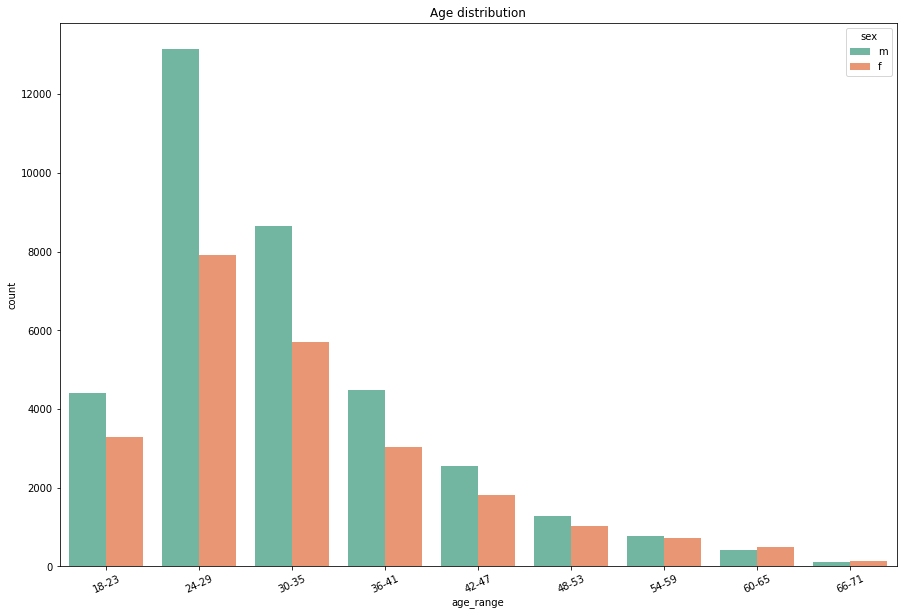

```python
plt.figure(figsize=(15, 10))

sns.countplot(x = 'age_range', data = data, hue = 'sex', palette='Set2')

plt.xticks(rotation = 25)
plt.title('Age distribution')
plt.show()
```

As we predicted, we can see the majority of users, both male and female are found to be 24-29 years old, causing the distribution to be right skewed.

Now let's take a look at the drinking scene. We can do this by using a pie chart and counting the the number of user in each response.

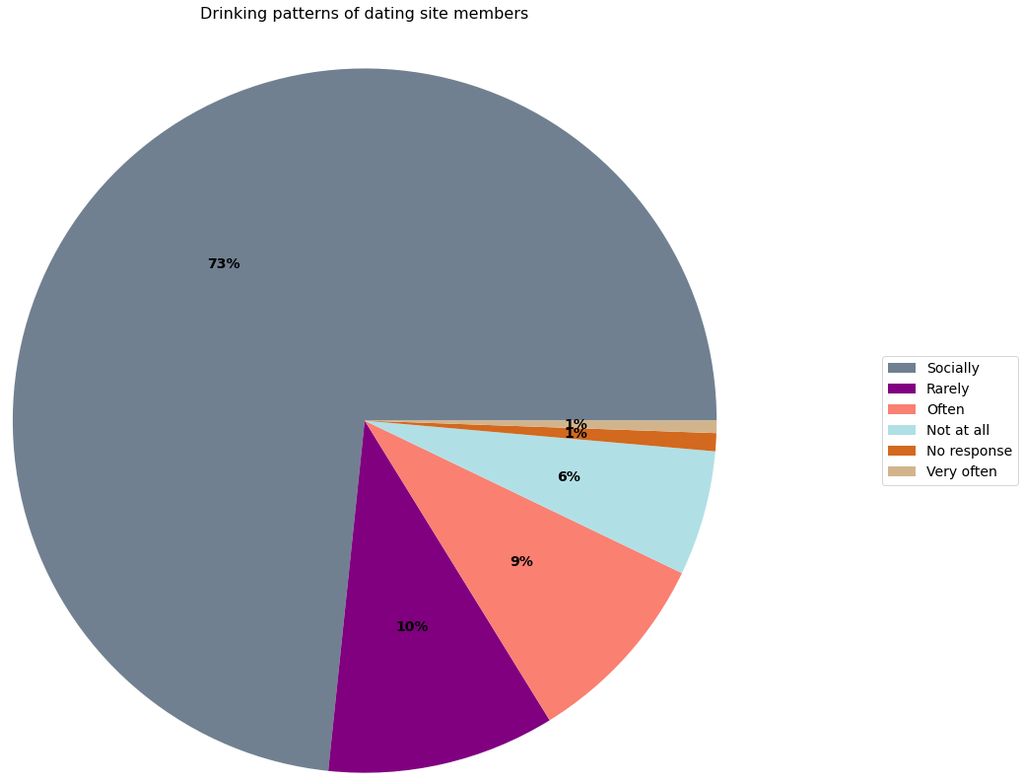

```python
plt.figure(figsize=(8, 10))

value_counts = data['drinks'].value_counts()

drinks_labels = ['Socially', 'Rarely', 'Often', 'Not at all', 'No response', 'Very often', 'Desperately']

colors = ['slategray', 'purple', 'salmon','powderblue', 'chocolate', 'tan', 'black']

plt.pie(value_counts, colors = colors, radius = 2.0, autopct='%1.0f%%', counterclock = True, textprops = {'color': 'black', 'weight': 'bold', 'fontsize': 14})

plt.legend(labels = drinks_labels, bbox_to_anchor = (2, 0.5), loc = 'right', fontsize = 14)

plt.title('Drinking patterns of dating site members', y = 1.4, fontsize = 16)
plt.savefig('drinking_patterns', bbox_inches = 'tight')
```

We can notice here an overwhelming amount of people socially drink. Drinking would be an interesting feature to test on its correlation to the status. We will be using this information later!

Let's continue taking a look at the drinks category. How is it looking in terms of age. We know that the majority of people on this app are arround 24-29. Will we see the same result with drinking?

Lets visualize this using a boxplot.

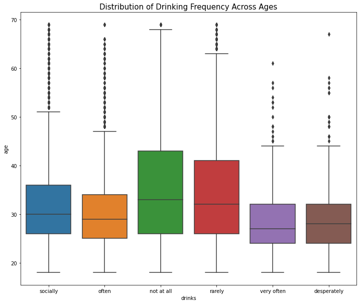

```python
plt.figure(figsize=(12, 10))
sns.boxplot(data=data, y="age", x="drinks")
plt.title('Distribution of Drinking Frequency Across Ages',fontsize = 15)
plt.show()
```

Is this something you might have expected? The younger the age, the more often they drink, while those who are older tend to drink more occasionally. The average drinking age seems to be around 30 years old.

Let's take a look at some other categories.

What is the majority orientation seen on this application? Let's take a look and even see the counts based on the sex. We can use count plot again.

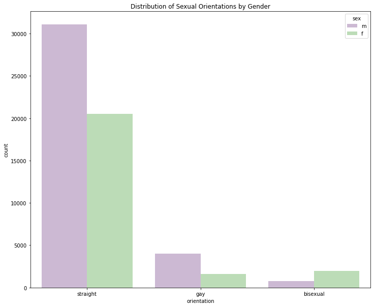

```python
plt.figure(figsize=(12, 10))
ax = sns.countplot(x='orientation', data=data, hue='sex', palette='PRGn',
                   order=data['orientation'].value_counts().iloc[:10].index)

plt.title('Distribution of Sexual Orientations by Gender',fontsize = 12)

plt.show()
```

As we can see overwhelmingly, the majority of users on this app are straight. Considering that this dataset is from 2012, how would this compare to a dataset that is more recent?

Our next stop is religion! What religion to our users on this app practice? This will be another category we will further analyze. We will visualize this using a histogram.

We also want to make sure we can drop the null values and strings that are null for this to work properly.

As you will see later on, our decision on what we do for null values, is to simply drop this. It seems like the best course of action, as it would not make sense to replace them with another value as that could incorrectly represent a user.

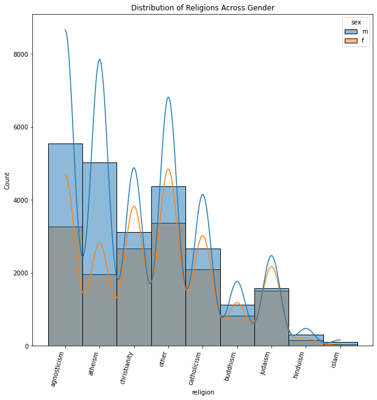

```
array(['agnosticism', nan, 'atheism', 'christianity', 'other',
       'catholicism', 'buddhism', 'judaism', 'hinduism', 'islam'],
      dtype=object)
```

```python
plt.figure(figsize=(10, 10))
df = data
mask = pd.isna(df['religion'])

# We need to drop null values as well as strings that are null ('nan')
df['religion'] = df['religion'].dropna()
df = df.drop(df[df["religion"].isin(['nan'])].index)


ax = sns.histplot(x='religion', data=df, kde=True, hue = 'sex')
plt.xticks(rotation=75, ha="right", position=(.05, 0))
plt.title('Distribution of Religions Across Gender', fontsize = 12)

plt.show()


data['religion'].unique()
```

Let's take a look at the incomes of users. This would also be an interesting category to see its correlation with status. Do most people care about the income?

We can take a look at this using a line graph, plotting the number of people with a certain income.

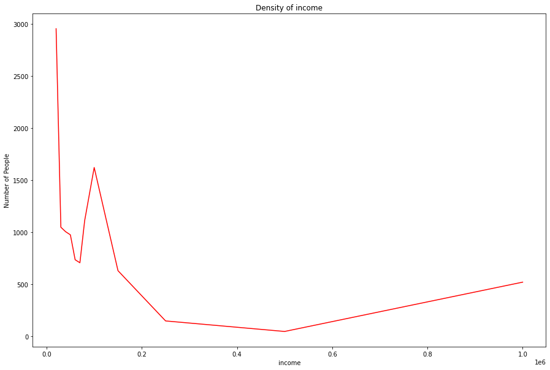

```python
#Graph the density of incomes
plt.figure(figsize=(15, 10))

value_counts = data['income'].value_counts()
#We need to get rid of the value containing -1, as this represents a null value
value_counts = value_counts.iloc[1:]
ax = sns.lineplot(data=value_counts, color='red')

#ax.set_xticklabels(ax.get_xticklabels(), rotation=270, ha="right")
plt.title('Density of income', fontsize = 12)


ax.set_ylabel("Number of People")
ax.set_xlabel("income")
plt.show()
```

How does astrology have an effect on status as well. Let's explore this area by looking at which users are taken/single based on their astrology sign.

We can do this by using the singles and taken tables we created earlier and taking a look at the signs. We can then count it, and then graph is using a plot bar.

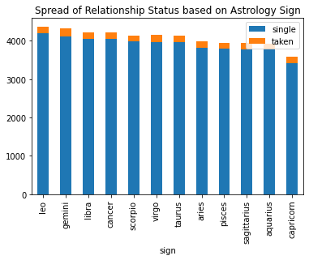

```python
# Graphing astrology sign counts
single_split = single["sign"].str.partition(" ")
single['sign_sig'] = single_split.iloc[:, 2]
single['sign'] = single_split.iloc[:, 0]


taken_split = taken["sign"].str.partition(" ")
taken['sign_sig'] = taken_split.iloc[:, 2]
taken['sign'] = taken_split.iloc[:, 0]

singlevals = single['sign'].value_counts()
takenvals = taken['sign'].value_counts()


series_list = [singlevals, takenvals]

# putting the singlevals and takenvals together
sign_counts = pd.concat(series_list, axis = 1)
sign_counts = sign_counts.reset_index()
sign_counts.columns = ['sign', 'single', 'taken']


# show the plot


sign_counts.plot.bar(x="sign", y=["single", "taken"], stacked=True)

plt.title('Spread of Relationship Status based on Astrology Sign', fontsize = 12)


plt.show()
```

As we can see, there is a pretty even distribution of astrology assigns across dating profiles. Does this mean that astrology is not a huge determining factor for matches?

Lastly, lets take a look at diet. The responses in diet are quite numerous, so for ease of graphing, we will simplify the responses by dictating something like "strictly vegetarian" is just vegetarian.

We can do this by using a dictionary and mapping its respective values to right values. We can than sort by the different diet groups we created and graph it.

In this scenario, we can use a simple bar graph to see the number of users in each diet group.

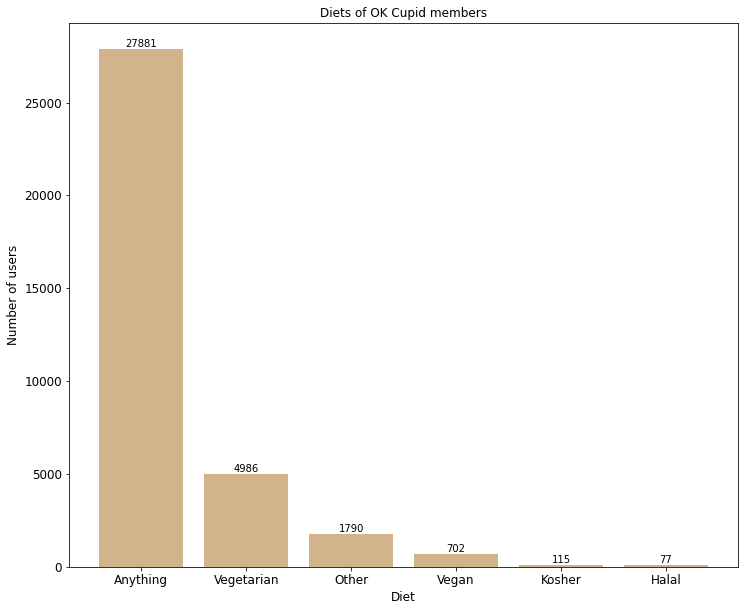

```python
diet = data.groupby('diet').size().sort_values(ascending = False).to_frame().reset_index().rename(columns = \
                                                                                                    {0: 'diet_count'})
#diet dataframe has lots of similar diets - creating an extra column to group some of these using a dictionary method
diet_dictionary = {'no response given': 'No response',
                    'mostly anything': 'Anything',
                    'anything': 'Anything',
                    'strictly anything': 'Anything',
                    'mostly vegetarian': 'Vegetarian',
                    'mostly other': 'Other',
                    'strictly vegetarian': 'Vegetarian',
                    'vegetarian': 'Vegetarian',
                    'strictly other': 'Other',
                    'mostly vegan': 'Vegan',
                    'other': 'Other',
                    'strictly vegan': 'Vegan',
                    'vegan': 'Vegan',
                    'mostly kosher': 'Kosher',
                    'mostly halal': 'Halal',
                    'strictly kosher': 'Kosher',
                    'strictly halal': 'Halal',
                    'kosher': 'Kosher',
                  'halal': 'Halal'}

diet['diet_group'] = diet['diet'].map(diet_dictionary)


#grouping by the new diet column
diet_group = diet.groupby('diet_group').diet_count.sum().sort_values(ascending = False).to_frame().reset_index()
diet_group


plt.figure(figsize=(12, 10))



for i, d in enumerate(diet_group['diet_count']):
    plt.text(i, d, str(d), ha='center', va='bottom')

plt.bar(diet_group['diet_group'], diet_group['diet_count'], color = 'tan')

plt.xlabel('Diet', fontsize = 12)
plt.ylabel('Number of users', fontsize = 12)
plt.title('Diets of OK Cupid members', fontsize = 12)
plt.tick_params(axis = 'x', labelsize = 12)
plt.tick_params(axis = 'y', labelsize = 12)
```

Most users will eat anything. Would a certain type of diet affect a users status? Would users prefer that their partner have the same diet as them or totally against a specific diet? These are good questions to ask.

# Part 4: Hypothesis Testing

We want to see what category has the largest effect in predicting the status of an user. To do this we will do some hypothesis testing. We will take a look at the correlations and then take a look at the p-values of each category. Lets start by stating all the hypothesis

Diet

Ho: Diet has no effect in predicting status of an user

Ha: Diet has an effect in predicting status of an user

Drinks

Ho: Drinking has no effect in predicting status of an user

Ha: Drinking has an effect in predicting status of an user

Religion

Ho: Religion has no effect in predicting status of an user

Ha: Religion has an effect in predicting status of an user

Sign

Ho: Sign has no effect in predicting status of an user

Ha: Sign has an effect in predicting status of an user

Income

Ho: Income has no effect in predicting status of an user

Ha: Income has an effect in predicting status of an user

We will begin by looking at the correlation between the user status and the choice of these categories: diet, drinks, religion, sign, and income.

First, lets take a look at how many rows in these specific columns contain null. We decided that the best course of action is to drop them.

To do this, we can find out how many nulls we currently have.

The status column has a unknown value that basically represents null, so lets replace that with a null so that those rows can drop as well.

```python
# correlation between user status and the following features: diet, drinks, religion, sign, income

# checking how many nulls/NaN are in these columns that we will be using
np.sum(data[['status', 'religion', 'diet', 'drinks', 'income', 'sign']].isna() == True)
# There are some status with unknowns, which is basically null, so lets replace that
data['status'] = data['status'].replace({"unknown": np.nan})

# Now lets drop all the nulls/NaN to work with the dataset easily
new_data = data.dropna(subset=['status', 'religion', 'diet', 'drinks', 'income', 'sign'], axis=0)

# We will see that there is no more nulls
np.sum(new_data[['status','religion', 'diet', 'drinks', 'income', 'sign']].isna() == True)
```

```
status      0
religion    0
diet        0
drinks      0
income      0
sign        0
dtype: int64
```

We were able to hot encode all the categories we are looking at except diet. We can do that using the dictionary that we had used earlier for one of our graphs.

We will map it to its more concise definition and then hot encode it using the process we used earlier.

```python
# diet_dictionary = {'no response given': 'No response',
#                     'mostly anything': 'Anything',
#                     'anything': 'Anything',
#                     'strictly anything': 'Anything',
#                     'mostly vegetarian': 'Vegetarian',
#                     'mostly other': 'Other',
#                     'strictly vegetarian': 'Vegetarian',
#                     'vegetarian': 'Vegetarian',
#                     'strictly other': 'Other',
#                     'mostly vegan': 'Vegan',
#                     'other': 'Other',
#                     'strictly vegan': 'Vegan',
#                     'vegan': 'Vegan',
#                     'mostly kosher': 'Kosher',
#                     'mostly halal': 'Halal',
#                     'strictly kosher': 'Kosher',
#                     'strictly halal': 'Halal',
#                     'kosher': 'Kosher',
#                   'halal': 'Halal'}

# Remember this diet dictionary? Lets map these properly in our new data set and then one-hot encode them as we have done before.

data_status_labels = new_data.assign(diet_labels = new_data.diet.map(diet_dictionary))
le = LabelEncoder()
# # fit the encoder to the DataFrame column
le.fit(data_status_labels['diet_labels'])
# apply the encoding to the column and store the transformed values
data_status_labels['diet_value'] = le.transform(data_status_labels['diet_labels'])
tmp = {i: cat for i, cat in enumerate(le.classes_)}
mappings['diet'] = tmp
```

We should also simplify our statuses to just s, representing single and t, representing taken.

We will create a new table called data_status_labels to begin our machine learning process.

```python
# we will map our values to s and t
s = ['single', 'available']
t = ['seeing someone', 'married']
# creating the dictionary, very similar to what we did with the diet dictionary
status_map = {'single': 's',
              'available': 's',
              'seeing someone': 't',
              'married': 't'}
data_status_labels = data_status_labels.assign(status_labels = data_status_labels.status.map(status_map))
data_status_labels.status_labels.value_counts()
data_status_labels.head()
```

|  | age | status | sex | orientation | body_type | diet | drinks | drugs | education | ethnicity | ... | sign_sig | religion_sig | sign_value | religion_value | drinks_value | income_value | age_range | diet_labels | diet_value | status_labels |
| --- | --- | --- | --- | --- | --- | --- | --- | --- | --- | --- | --- | --- | --- | --- | --- | --- | --- | --- | --- | --- | --- |
| 0 | 22 | single | m | straight | a little extra | strictly anything | socially | never | working on college/university | asian, white | ... |  | and very serious about it | 4 | 0 | 4 | 0 | 18-23 | Anything | 0 | s |
| 1 | 35 | single | m | straight | average | mostly other | often | sometimes | working on space camp | white | ... |  | but not too serious about it | 2 | 0 | 2 | 7 | 30-35 | Other | 3 | s |
| 5 | 29 | single | m | straight | average | mostly anything | socially | NaN | graduated from college/university | white | ... |  |  | 10 | 1 | 4 | 0 | 24-29 | Anything | 0 | s |
| 7 | 31 | single | f | straight | average | mostly anything | socially | never | graduated from college/university | white | ... |  |  | 8 | 4 | 4 | 0 | 30-35 | Anything | 0 | s |
| 8 | 24 | single | f | straight | NaN | strictly anything | socially | NaN | graduated from college/university | white | ... | but it doesn&rsquo;t matter | but not too serious about it | 4 | 4 | 4 | 0 | 24-29 | Anything | 0 | s |

5 rows × 33 columns

We are only dealing with a couple columns, so lets just drop every other column we aren't using to see it better.

```python
data_status_labels.drop(columns=['body_type', 'drugs', 'education', 'ethnicity', 'profile text', 'Total Words', 'job', 'height', 'orientation', 'last_online', 'speaks', 'smokes', 'pets', 'offspring', 'location', 'sign_sig'], axis=1, inplace=True)
```

```python
# These are the columns we are working with, so lets just organize it, when we look at the data sets.
data_status_labels = data_status_labels[['age', 'status', 'sex', 'diet', 'drinks', 'income', 'religion', 'sign', 'status_labels', 'diet_value', 'drinks_value', 'income_value', 'religion_value', 'sign_value']]
data_status_labels = data_status_labels.reset_index()
```

Now we will start preparing the features we are using by scaling the dataset. This is useful when we use K Nearest Neighbors. This article does a good job at explaining why scaling is important: [Scaling Data](https://towardsdatascience.com/what-and-why-behind-fit-transform-vs-transform-in-scikit-learn-78f915cf96fe).

As a summary:

"The fit method is calculating the mean and variance of each of the features present in our data. The transform method is transforming all the features using the respective mean and variance."

This will in the end allow us to get a good estimate of the performance of our data.

```python
df_features_all = data_status_labels[['diet_value', 'drinks_value', 'income_value', 'religion_value', 'sign_value']]
x = df_features_all.values
min_max_scaler = preprocessing.MinMaxScaler()
x_scaled = min_max_scaler.fit_transform(x)
df_features_all = pd.DataFrame(x_scaled, columns=df_features_all.columns)
df_labels = data_status_labels['status_labels']
df_features_all.head()
```

|  | diet_value | drinks_value | income_value | religion_value | sign_value |
| --- | --- | --- | --- | --- | --- |
| 0 | 0.0 | 0.8 | 0.000000 | 0.000 | 0.363636 |
| 1 | 0.6 | 0.4 | 0.583333 | 0.000 | 0.181818 |
| 2 | 0.0 | 0.8 | 0.000000 | 0.125 | 0.909091 |
| 3 | 0.0 | 0.8 | 0.000000 | 0.500 | 0.727273 |
| 4 | 0.0 | 0.8 | 0.000000 | 0.500 | 0.363636 |

We can look at the correlations between each feature by using a heat map.

```python
# gathering the correlations of all the features
rel = df_features_all.corr()

# heat map
table = rel.style.background_gradient(cmap='Blues').format('{0:,.2f}')
table
```

|  | diet_value | drinks_value | income_value | religion_value | sign_value |
| --- | --- | --- | --- | --- | --- |
| diet_value | 1.00 | -0.06 | -0.02 | 0.06 | -0.01 |
| drinks_value | -0.06 | 1.00 | -0.01 | -0.04 | 0.00 |
| income_value | -0.02 | -0.01 | 1.00 | 0.00 | -0.00 |
| religion_value | 0.06 | -0.04 | 0.00 | 1.00 | -0.00 |
| sign_value | -0.01 | 0.00 | -0.00 | -0.00 | 1.00 |

Now we will take a look at the correlation between the features and its status.

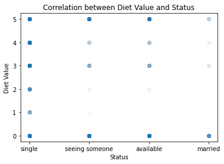

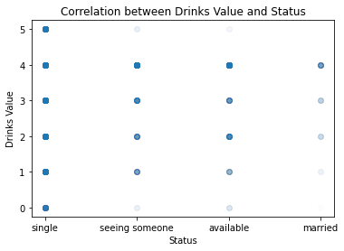

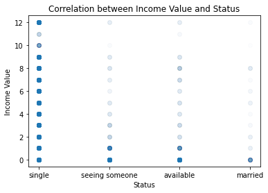

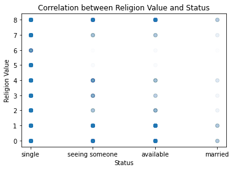

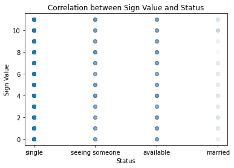

```python
features = [data_status_labels.diet_value, data_status_labels.drinks_value, data_status_labels.income_value, data_status_labels.religion_value, data_status_labels.sign_value]
names = ['Diet Value', 'Drinks Value', 'Income Value', 'Religion Value', 'Sign Value']
count = 0
for f in features:

    #labeling and plotting
    plt.figure()
    plt.scatter(data_status_labels.status, f, alpha = 0.01)
    plt.xlabel('Status')
    plt.ylabel(names[count])
    plt.title('Correlation between ' + names[count] + ' and Status')

    #putting name of teams next to points
    count += 1
    #plotting

    plt.show()
```

Now, lets calculate our p-values for our hypothesis and determine whether we will end up rejecting or failing to reject the null hypothesis. We will be using a spearman rank correlation coefficient to get the p-values. This is because we have a numerical value and a categorical value and this will be able to accomodate for that. A pearson correlation coefficient, which may be more commonly used, deals with only continous values.

Take a look at this resource to better understand spearman: [Spearman Rank Correlation Coefficient](https://statistics.laerd.com/statistical-guides/spearmans-rank-order-correlation-statistical-guide.php)

```python
from scipy.stats import spearmanr
data_status_labels
# drinks
p_value_arr = []
correlation, p_value = spearmanr(data_status_labels['drinks_value'], data_status_labels['status_labels'])
print("Drinks correlation: ", correlation)
print("Drinks P-Value:", f'{p_value:.20f}')
p_value_arr.append(p_value)
correlation, p_value = spearmanr(data_status_labels['sign_value'], data_status_labels['status_labels'])
print("Sign correlation: ", correlation)
print("Signs P-value:", f'{p_value:.20f}')
p_value_arr.append(p_value)
correlation, p_value = spearmanr(data_status_labels['religion_value'], data_status_labels['status_labels'])
print("Religion correlation: ", correlation)
print("Religion P-value: ", f'{p_value:.20f}')
p_value_arr.append(p_value)
correlation, p_value = spearmanr(data_status_labels['income_value'], data_status_labels['status_labels'])
print("Income correlation: ", correlation)
print("Income P-value: ", f'{p_value:.20f}')
p_value_arr.append(p_value)
correlation, p_value = spearmanr(data_status_labels['diet_value'], data_status_labels['status_labels'])
print("Diet correlation: ", correlation)
print("Diet P-value: ", f'{p_value:.20f}')
p_value_arr.append(p_value)

print("Lowest p_value", f'{min(p_value_arr):.20f}')
```

```
Drinks correlation:  -0.036417573601385686
Drinks P-Value: 0.00000005894766575153
Sign correlation:  0.010862124772683616
Signs P-value: 0.10594327117487917223
Religion correlation:  -0.021667002190454043
Religion P-value:  0.00125901912984679792
Income correlation:  0.023366586931788908
Income P-value:  0.00050476907314090226
Diet correlation:  0.041103440052102494
Diet P-value:  0.00000000093477071618
Lowest p_value 0.00000000093477071618
```

This leads us to conclude that diet has the most statistical significance in predicting status.

### K Nearest Neighbhor

For our algorithm, we will be implementing a K Nearest Neighbhor. K-Nearest Neighbors (KNN) is a simple and effective classification algorithm that can be used for a variety of tasks. It works by finding the K nearest data points in the training set for a given sample in the test set, and then predicting the label of the sample based on the labels of its nearest neighbors. KNN has several attractive properties, including that it is easy to implement and understand, and it often performs well even with relatively small amounts of training data.

Using KNN for classification on the OK Cupid data will be beneficial if the data is structured in a way that allows KNN to make accurate predictions. For example, if the data points in the training set are well separated, such that each class is surrounded by points from the same class, then KNN may be able to accurately predict the labels of the test set samples based on their nearest neighbors. In addition, KNN may be particularly well suited for this data set if the relationships between the features and the labels are relatively simple and non-linear, as KNN is known to work well with such data.

Lets now do a K Nearest Neighbor (KNN) algorithm on this data.

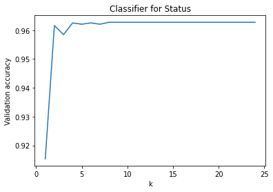

```python
training_data, validation_data, training_labels, validation_labels = train_test_split(df_features_all, df_labels, test_size = 0.2, random_state = 100)
accuracies = []
for k in range(1,25):
    knn = KNeighborsClassifier(n_neighbors=k)
    knn.fit(training_data, training_labels.values.ravel())
    knn_score = knn.score(validation_data, validation_labels)
    accuracies.append(knn_score)

#
plt.plot(range(1,25), accuracies)
plt.xlabel('k')
plt.ylabel('Validation accuracy')
plt.title('Classifier for Status')
plt.show()
```

```python
print(max(accuracies)) # This is the max of this graph, gets hit around a k-value of 8.
```

```
0.962762356127285
```

This is a large number! This is the highest accuracy we get from this algorithm, and it does pretty well at predicting the status.

Lets walk through how this code works.

The data is first split into training and validation sets using the train_test_split function from the sklearn.model_selection module. The function takes in the features (df_features_all) and labels (df_labels) of the data, and the desired size of the validation set (specified as a fraction of the total data with the test_size parameter, in this case 0.2 or 20%). The random_state parameter is used to specify a seed for the random number generator, so that the same split is obtained every time the code is run.

The KNN classifier is then trained and evaluated in a loop, where the number of neighbors (k) is varied from 1 to 24. For each value of k, a KNN classifier object is created using KNeighborsClassifier from the sklearn.neighbors module, and the classifier is trained on the training data using the fit method. The classifier's performance is then evaluated on the validation data using the score method, which returns the accuracy of the classifier (i.e., the fraction of correctly classified samples). The accuracy is stored in a list called accuracies.

Finally, a plot is generated showing how the validation accuracy changes with the number of neighbors. The plot is created using the plot function from the matplotlib.pyplot module, which takes in the range of k values and the corresponding accuracies as its arguments. The plot is labeled and given a title using the xlabel, ylabel, and title functions, respectively. The plot is then displayed using the show function.

### Random Forest

We can also try using a random forest calssifier as another method for determining accuracy.

A random forest is a type of machine learning model that is used for classification and regression tasks. It is an ensemble learning method, which means that it is composed of multiple individual models (called decision trees) that are trained on different subsets of the data and then combined to make predictions.

Random forests are useful for a variety of tasks, including predicting the likelihood of an event based on a set of predictors (e.g., whether a user will respond to a message on a dating site), estimating the value of a continuous variable (e.g., predicting how compatible two users are based on their profiles), and identifying patterns and relationships in data (e.g., identifying factors that predict whether a user will initiate a conversation).

One of the benefits of using a random forest is that it can handle high-dimensional and complex data sets, and can effectively handle data that includes both categorical and numerical variables. It can also handle missing data and handle imbalanced data sets (where one class is much more prevalent than the other).

In the context of the OK Cupid data set, a random forest model might be useful for predicting which users are most likely to get in a relationship. It could also be used to identify factors that predict compatibility or success in relationships, such as diet type, religion, income, and more

```python
forest = RandomForestClassifier(random_state = 1)
forest.fit(training_data, training_labels.values.ravel())
print(forest.score(validation_data, validation_labels))
```

```
0.9596027984653577
```

This number is also pretty big! But it seems our KNN algorithm does a better job at predicting than Random Forest.

# Conclusion

Based on the results of a statistical analysis, it appears that diet is the most significant predictor of the chance of being in a relationship. This conclusion is supported by the fact that the p-value for diet was the lowest among all of the predictors, indicating that the effect of diet on the chance of being in a relationship is statistically significant.

This suggests that diet plays an important role in determining the chance of being in a relationship, and that it is an important factor to consider when trying to predict this outcome. It is important to note, however, that other factors may also be important in predicting the chance of being in a relationship (such as drinking, income , religion ,etc), and that the relative importance of these factors may vary depending on the specific context and the population being studied.